# Practical Machine Learning

# Course Assignment - Week 4

### Load Libraries that will be used later on

```r
library(caret)
```

```r
library(ggplot2)
library(corrplot)
```

1. Load the data from the CSV Assuming that the data files are saved in the current/ working directory

```r
train_original <- read.csv("pml-training.csv")
test_original <- read.csv("pml-testing.csv")
```

Split the train dataset into 2 so that the training model can be tested

```r
inTrain  <- createDataPartition(train_original$classe, p=0.7, list=FALSE)
to_train <- train_original[inTrain, ]
to_test <- train_original[-inTrain,]
```

Perform some diagnostics

```r
dim(to_train)
```

```
## [1] 13737   160
```

```r
dim(to_test)
```

```
## [1] 5885  160
```

2. Clean the data Near zero variance variables will be removed as well

```r
ZeroVariance <- nearZeroVar(to_train)
to_train <- to_train[,-ZeroVariance]
to_test <- to_test[,-ZeroVariance]
```

Find variables that have all lot of NAs

```r
Var_Names <- names(to_train[,colSums(is.na(to_train)) == 0])
to_train <- to_train[,Var_Names]
to_test <- to_test[,Var_Names]
```

Remove the first 5 variables because they relate to the person performing the test (username/ time_stamp etc). There is no prediction power in those variables

```r
to_train <- to_train[, -(1:5)]
to_test <- to_test[, -(1:5)]
```

Check the dimension of the final tables

```r
dim(to_train)
```

```
## [1] 13737    54
```

```r
dim(to_test)
```

```
## [1] 5885   54
```

The resulting dataset has 54 variables

3. Correlation Analysis Calculate the correlation of each variable and plot it Correlatrions are calciated on numeric data only

```r
to_train_numeric <- to_train[, sapply(to_train, is.numeric)]
correlations <- cor(to_train_numeric, use="pairwise", method="spearman")
round(correlations, 2)
```

[output not shown]

[output cut: 809 more lines]

[output not shown]

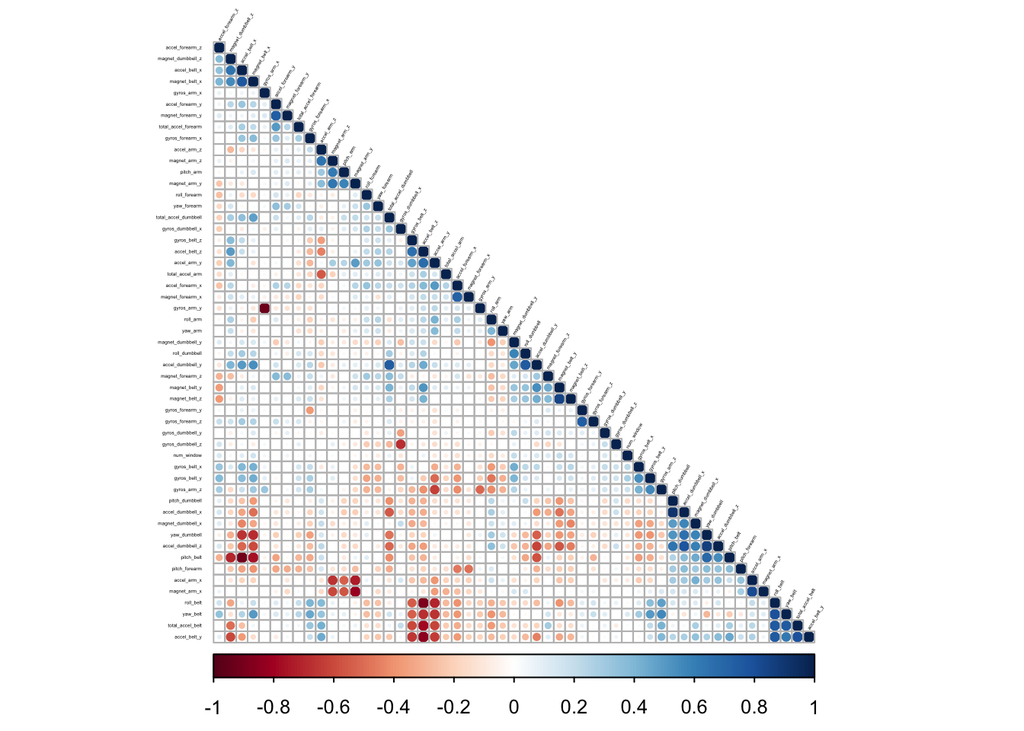

```r
corrplot(correlations, type = "lower", order = "hclust", method = "circle",
         tl.col = "black", tl.srt = 60, tl.cex = 0.2)
```

4. Prediction Model Builsing For this analysis to_train and to_test modles will be used in order to create a Prediction Model

# GMB

```r
set.seed(444)

modFitGBM <- train(classe ~ ., data=to_train, method="gbm", verbose = FALSE,
   trControl = trainControl(method = "repeatedcv", number = 5, repeats = 1))
modFitGBM$finalModel
```

```
## A gradient boosted model with multinomial loss function.
## 150 iterations were performed.
## There were 53 predictors of which 38 had non-zero influence.
```

```r
predictGBM <- predict(modFitGBM, to_test)
matrixGBM <- confusionMatrix(predictGBM, to_test$classe)
matrixGBM
```

```
## Confusion Matrix and Statistics
##
##           Reference
## Prediction    A    B    C    D    E
##          A 1673   13    0    1    2
##          B    0 1117   13    7    5
##          C    0    9 1003    5    1
##          D    1    0    9  950    9
##          E    0    0    1    1 1065
##
## Overall Statistics
##
##                Accuracy : 0.9869
##                  95% CI : (0.9837, 0.9897)
##     No Information Rate : 0.2845
##     P-Value [Acc > NIR] : < 2.2e-16
##
##                   Kappa : 0.9834
##  Mcnemar's Test P-Value : NA
##
## Statistics by Class:
##
##                      Class: A Class: B Class: C Class: D Class: E
## Sensitivity            0.9994   0.9807   0.9776   0.9855   0.9843
## Specificity            0.9962   0.9947   0.9969   0.9961   0.9996
## Pos Pred Value         0.9905   0.9781   0.9853   0.9804   0.9981
## Neg Pred Value         0.9998   0.9954   0.9953   0.9972   0.9965
## Prevalence             0.2845   0.1935   0.1743   0.1638   0.1839
## Detection Rate         0.2843   0.1898   0.1704   0.1614   0.1810
## Detection Prevalence   0.2870   0.1941   0.1730   0.1647   0.1813
## Balanced Accuracy      0.9978   0.9877   0.9872   0.9908   0.9919
```

## Decision Tree

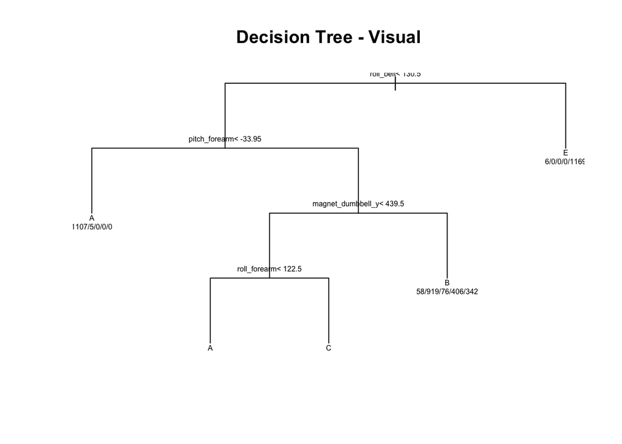

```r
set.seed(444)

modFitDT <- train(classe ~ ., data=to_train, method="rpart")

plot(modFitDT$finalModel, uniform = TRUE,
      main = "Decision Tree - Visual")
text(modFitDT$finalModel, use.n = TRUE, cex=.5)
```

```r
predictDT <- predict(modFitDT, to_test)
matrixDT <- confusionMatrix(predictDT, to_test$classe)
matrixDT
```

```
## Confusion Matrix and Statistics
##
##           Reference
## Prediction    A    B    C    D    E
##          A 1510  486  486  440  154
##          B   23  367   32  162  144
##          C  133  286  508  362  322
##          D    0    0    0    0    0
##          E    8    0    0    0  462
##
## Overall Statistics
##
##                Accuracy : 0.4838
##                  95% CI : (0.4709, 0.4966)
##     No Information Rate : 0.2845
##     P-Value [Acc > NIR] : < 2.2e-16
##
##                   Kappa : 0.3252
##  Mcnemar's Test P-Value : NA
##
## Statistics by Class:
##
##                      Class: A Class: B Class: C Class: D Class: E
## Sensitivity            0.9020  0.32221  0.49513   0.0000  0.42699
## Specificity            0.6281  0.92394  0.77300   1.0000  0.99833
## Pos Pred Value         0.4909  0.50412  0.31533      NaN  0.98298
## Neg Pred Value         0.9416  0.85030  0.87880   0.8362  0.88550
## Prevalence             0.2845  0.19354  0.17434   0.1638  0.18386
## Detection Rate         0.2566  0.06236  0.08632   0.0000  0.07850
## Detection Prevalence   0.5227  0.12370  0.27375   0.0000  0.07986
## Balanced Accuracy      0.7651  0.62307  0.63406   0.5000  0.71266
```

## Random Forest

```r
set.seed(444)

modFitRF <- train(classe ~., data = to_train, method="rf", ntree = 1000)
predictRF <- predict(modFitRF, to_test)
matrixRF <- confusionMatrix(predictRF,to_test$classe)
matrixRF
```

[output not shown]

```r
final_prediction <- predict(modFitRF,test_original)
final_prediction
```

[output not shown]